# Replicability and Journal Impact Factor

Author

Jessica Röseler

```r
###############################################################################
# 1. filter irrelevant flora studies
###############################################################################

flora_studies <- flora_studies[flora_studies$outcome %in% c("successful","failed"),]

flora_studies <- flora_studies[flora_studies$impact_factor<35,]

table(flora_studies$outcome)
```

```
    failed successful
       709        806
```

```r
table(flora_studies$outcome)/length(flora_studies$outcome)
```

```
    failed successful
 0.4368453  0.4966112
```

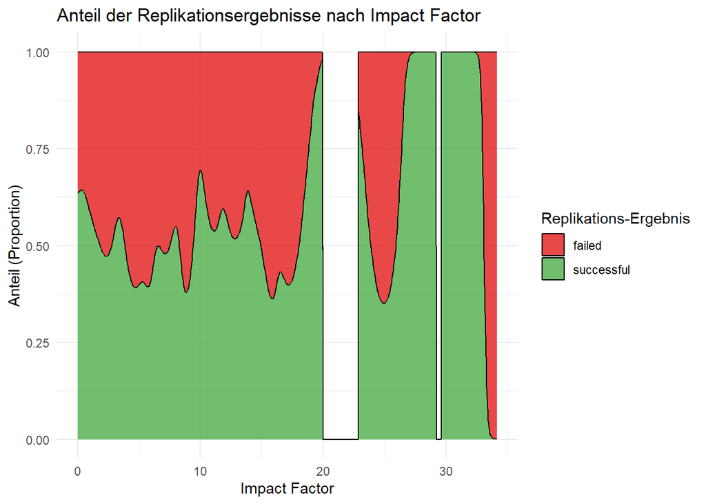

```r
###############################################################################
# 2. descriptive analysis with 2 outcomes(failed vs successful) -------------
###############################################################################
flora_studies$outcome_fac_bin <- factor(flora_studies$outcome,
                                      levels = c("failed", "successful"))
plot_data <- flora_studies[flora_studies$outcome %in% c("failed", "successful"),]
ggplot(plot_data, aes(x = impact_factor, fill = outcome_fac_bin)) +
  geom_density(position = "fill", alpha = 0.8) +
  scale_fill_manual(values = c("failed" = "#e41a1c", "successful" = "#4daf4a"),
                    name = "Replikations-Ergebnis") +
  labs(title = "Anteil der Replikationsergebnisse nach Impact Factor",
       x = "Impact Factor",
       y = "Anteil (Proportion)") +
  theme_minimal()
```

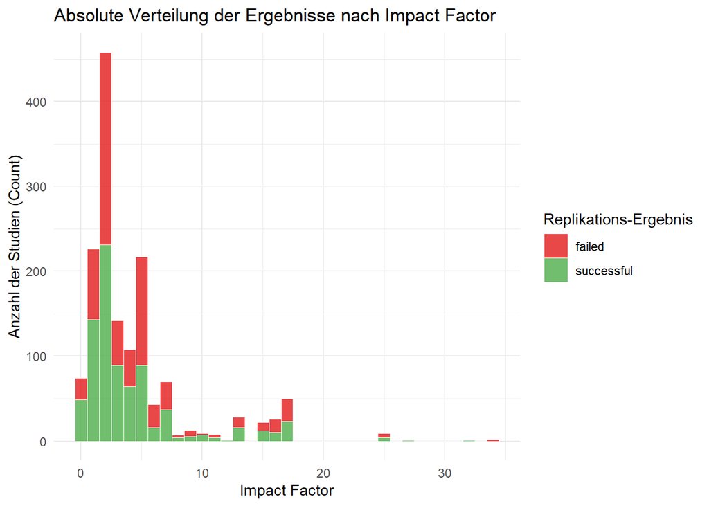

```r
ggplot(plot_data, aes(x = impact_factor, fill = outcome_fac_bin)) +
  geom_histogram(position = "stack", binwidth = 1, alpha = 0.8, color = "white", linewidth = 0.1) +
  scale_fill_manual(values = c("failed" = "#e41a1c",
                               "successful" = "#4daf4a"),
                    name = "Replikations-Ergebnis") +
  labs(title = "Absolute Verteilung der Ergebnisse nach Impact Factor",
       x = "Impact Factor",
       y = "Anzahl der Studien (Count)") +
  theme_minimal()
```

```r
###############################################################################
# 3. Model 2 outcomes(failed vs successful) -------------
###############################################################################

flora_studies$outcome_binary <- ifelse(flora_studies$outcome == "failed", 0, ifelse(flora_studies$outcome == "successful", 1, NA))
flora_studies$impact_factor_log <- log(flora_studies$impact_factor+1)

sum(is.na(flora_studies$impact_factor))
```

```
[1] 108
```

```r
sum(flora_studies$impact_factor == 0, na.rm = TRUE)
```

```
[1] 43
```

```r
# is log impact factor necessary for logreg?
flora_bt2 <- flora_studies[flora_studies$impact_factor > 0, ]
flora_bt2$bt_term_raw <- flora_bt2$impact_factor * log(flora_bt2$impact_factor)

log_reg_bt_raw <- glm(outcome_binary ~ impact_factor + bt_term_raw,
                      family = binomial(link = "logit"),
                      data = flora_bt2)
summary(log_reg_bt_raw) #yes because bt_term is sig
```

```
Call:
glm(formula = outcome_binary ~ impact_factor + bt_term_raw, family = binomial(link = "logit"),
    data = flora_bt2)

Coefficients:
              Estimate Std. Error z value Pr(>|z|)
(Intercept)    0.53281    0.16073   3.315 0.000917 ***
impact_factor -0.20332    0.08220  -2.474 0.013378 *
bt_term_raw    0.05753    0.02628   2.189 0.028573 *
---
Signif. codes:  0 '***' 0.001 '**' 0.01 '*' 0.05 '.' 0.1 ' ' 1

(Dispersion parameter for binomial family taken to be 1)

    Null deviance: 2036.3  on 1471  degrees of freedom
Residual deviance: 2026.7  on 1469  degrees of freedom
  (108 Beobachtungen als fehlend gelöscht)
AIC: 2032.7

Number of Fisher Scoring iterations: 3
```

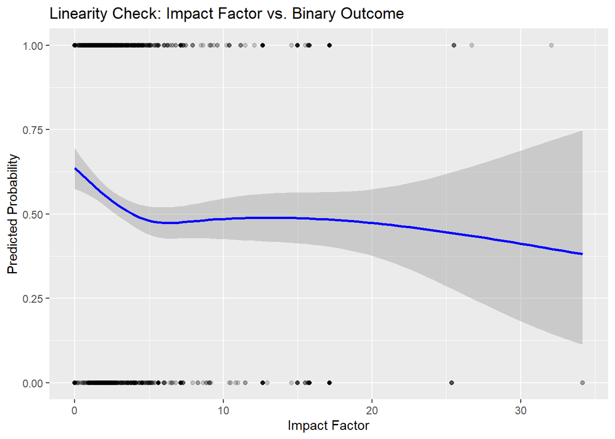

```r
ggplot(flora_studies, aes(x = impact_factor, y = outcome_binary)) +
  geom_point(alpha = 0.2) +
  geom_smooth(method = "gam", formula = y ~ s(x, bs = "cs"),
              method.args = list(family = binomial), color = "blue") +
  labs(title = "Linearity Check: Impact Factor vs. Binary Outcome",
       x = "Impact Factor", y = "Predicted Probability")
```

```r
# is logreg generally possible for log impact factor or is the preassumption of linearity between predictor and logodds still not met
flora_bt <- flora_studies[flora_studies$impact_factor_log > 0, ]
flora_bt$bt_term <- flora_bt$impact_factor_log * log(flora_bt$impact_factor_log)

log_reg_bt <- glm(outcome_binary ~ impact_factor_log + bt_term,
                  family = binomial(link = "logit"),
                  data = flora_bt)
summary(log_reg_bt)# pre requirement is given, logreg is possible
```

```
Call:
glm(formula = outcome_binary ~ impact_factor_log + bt_term, family = binomial(link = "logit"),
    data = flora_bt)

Coefficients:
                  Estimate Std. Error z value Pr(>|z|)
(Intercept)         0.9798     0.3991   2.455   0.0141 *
impact_factor_log  -0.7635     0.3906  -1.955   0.0506 .
bt_term             0.3551     0.2639   1.346   0.1784
---
Signif. codes:  0 '***' 0.001 '**' 0.01 '*' 0.05 '.' 0.1 ' ' 1

(Dispersion parameter for binomial family taken to be 1)

    Null deviance: 2036.3  on 1471  degrees of freedom
Residual deviance: 2025.2  on 1469  degrees of freedom
  (108 Beobachtungen als fehlend gelöscht)
AIC: 2031.2

Number of Fisher Scoring iterations: 4
```

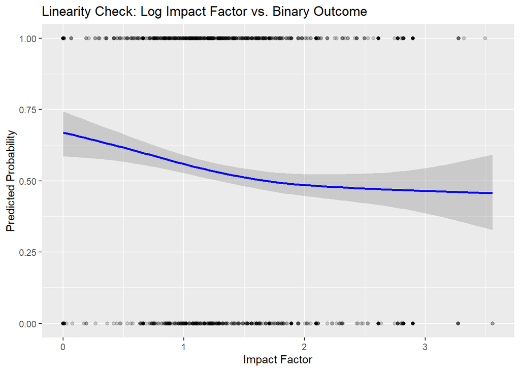

```r
ggplot(flora_studies, aes(x = impact_factor_log, y = outcome_binary)) +
  geom_point(alpha = 0.2) +
  geom_smooth(method = "gam", formula = y ~ s(x, bs = "cs"),
              method.args = list(family = binomial), color = "blue") +
  labs(title = "Linearity Check: Log Impact Factor vs. Binary Outcome",
       x = "Impact Factor", y = "Predicted Probability")
```

```r
# logistic regression with log impact factor
log_reg_FLorA_log <- glm(outcome_binary~impact_factor_log, family = binomial(link = "logit"), data = flora_studies)
summary(log_reg_FLorA_log)
```

```
Call:
glm(formula = outcome_binary ~ impact_factor_log, family = binomial(link = "logit"),
    data = flora_studies)

Coefficients:
                  Estimate Std. Error z value  Pr(>|z|)
(Intercept)        0.52855    0.12248   4.315 0.0000159 ***
impact_factor_log -0.28175    0.07803  -3.611  0.000305 ***
---
Signif. codes:  0 '***' 0.001 '**' 0.01 '*' 0.05 '.' 0.1 ' ' 1

(Dispersion parameter for binomial family taken to be 1)

    Null deviance: 2094.0  on 1514  degrees of freedom
Residual deviance: 2080.8  on 1513  degrees of freedom
  (108 Beobachtungen als fehlend gelöscht)
AIC: 2084.8

Number of Fisher Scoring iterations: 4
```

```r
#omni bus test
modelchi <- log_reg_FLorA_log$null.deviance - log_reg_FLorA_log$deviance
chidf <- log_reg_FLorA_log$df.null - log_reg_FLorA_log$df.residual
chisqp <- 1-pchisq(modelchi, chidf)
chisqp # model is significant overall
```

```
[1] 0.0002791
```

```r
# OR and 95% KI
exp(cbind(OR = coef(log_reg_FLorA_log), confint(log_reg_FLorA_log)))
```

```
                         OR     2.5 %    97.5 %
(Intercept)       1.6964765 1.3357426 2.1595029
impact_factor_log 0.7544632 0.6469206 0.8785948
```

```r
#model visualisation
pred_data <- data.frame(
  impact_factor = seq(min(flora_studies$impact_factor, na.rm = TRUE),
                      max(flora_studies$impact_factor, na.rm = TRUE),
                      length.out = 500)
)
pred_data$impact_factor_log <- log(pred_data$impact_factor + 1)

pred <- predict(log_reg_FLorA_log, newdata = pred_data,
                type = "link", se.fit = TRUE)
pred_data$prob    <- plogis(pred$fit)
pred_data$lower   <- plogis(pred$fit - 1.96 * pred$se.fit)
pred_data$upper   <- plogis(pred$fit + 1.96 * pred$se.fit)

# P=0.5 Threshold: β0 + β1*log(IF+1) = 0 → IF = exp(-β0/β1) - 1
b0 <- coef(log_reg_FLorA_log)[1]
b1 <- coef(log_reg_FLorA_log)[2]
threshold_IF <- exp(-b0 / b1) - 1
cat("P(success) = 0.5 | Impact Factor:", round(threshold_IF, 2), "\n")
```

```
P(success) = 0.5 | Impact Factor: 5.53
```

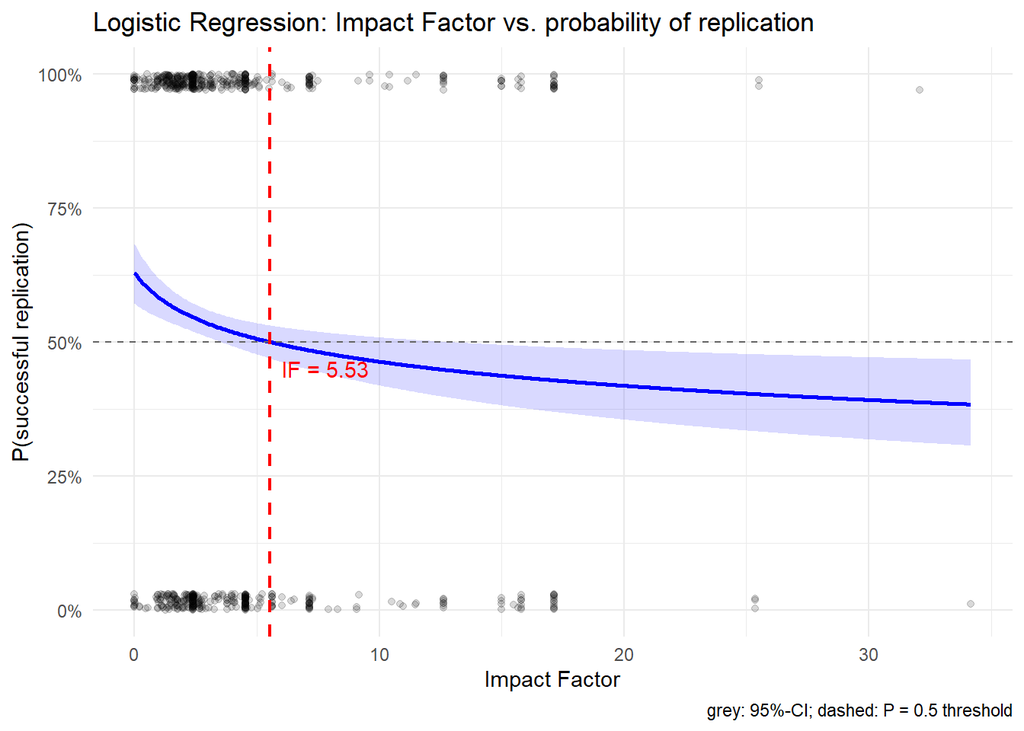

```r
ggplot(pred_data, aes(x = impact_factor)) +
  geom_ribbon(aes(ymin = lower, ymax = upper), fill = "blue", alpha = 0.15) +
  geom_line(aes(y = prob), color = "blue", linewidth = 1) +
  geom_jitter(data = flora_studies,
              aes(x = impact_factor, y = outcome_binary),
              alpha = 0.15, height = 0.03, width = 0) +
  geom_hline(yintercept = 0.5, linetype = "dashed", color = "gray40") +
  geom_vline(xintercept = threshold_IF, linetype = "dashed", color = "red",
             linewidth = 0.8) +
  annotate("text", x = threshold_IF + 0.5, y = 0.45,
           label = paste0("IF = ", round(threshold_IF, 2)),
           color = "red", hjust = 0) +
  scale_y_continuous(limits = c(0, 1), labels = scales::percent) +
  labs(title = "Logistic Regression: Impact Factor vs. probability of replication",
       x = "Impact Factor",
       y = "P(successful replication)",
       caption = "grey: 95%-CI; dashed: P = 0.5 threshold") +
  theme_minimal()
```

```r
#GAM model
modell_gam <- gam(outcome_binary ~ s(impact_factor_log), data = flora_studies, family = binomial)
summary(modell_gam)
```

```
Family: binomial
Link function: logit

Formula:
outcome_binary ~ s(impact_factor_log)

Parametric coefficients:
            Estimate Std. Error z value Pr(>|z|)
(Intercept)   0.1321     0.0520   2.541    0.011 *
---
Signif. codes:  0 '***' 0.001 '**' 0.01 '*' 0.05 '.' 0.1 ' ' 1

Approximate significance of smooth terms:
                       edf Ref.df Chi.sq  p-value
s(impact_factor_log) 7.578  8.475  28.67 0.000443 ***
---
Signif. codes:  0 '***' 0.001 '**' 0.01 '*' 0.05 '.' 0.1 ' ' 1

R-sq.(adj) =  0.0168   Deviance explained = 1.59%
UBRE = 0.37148  Scale est. = 1         n = 1515
```

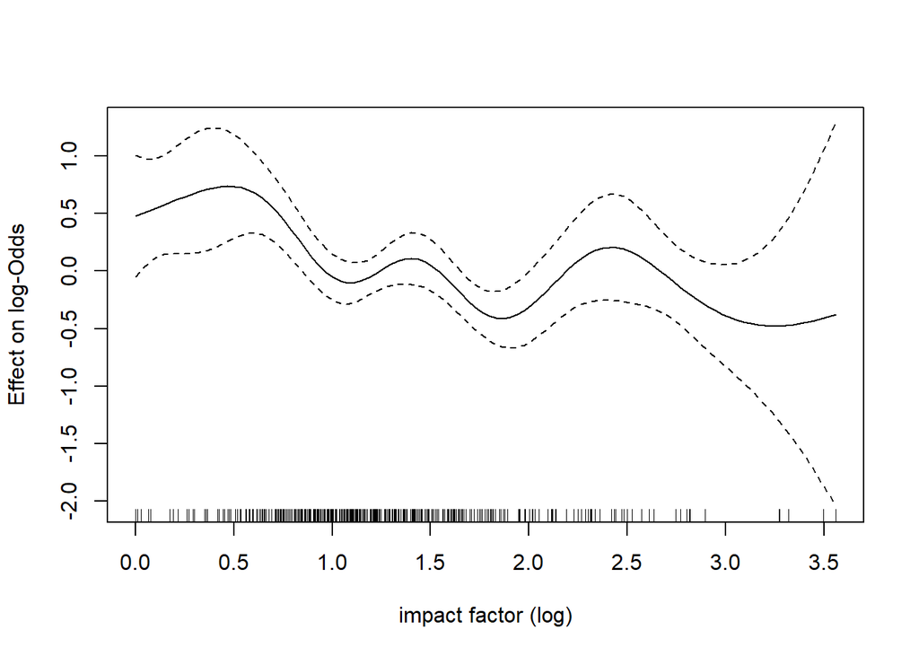

```r
plot(modell_gam, shade = TRUE,
     xlab = "impact factor (log)",
     ylab = "Effect on log-Odds")
```

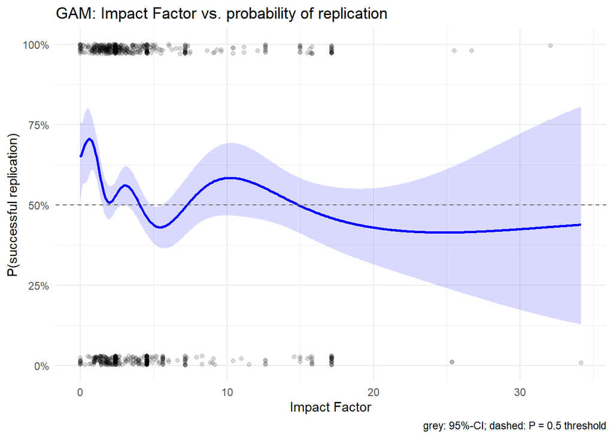

```r
# model prediction on original Impact Factor scale
pred_gam <- data.frame(
  impact_factor = seq(min(flora_studies$impact_factor, na.rm = TRUE),
                      max(flora_studies$impact_factor, na.rm = TRUE),
                      length.out = 500)
)
pred_gam$impact_factor_log <- log(pred_gam$impact_factor + 1)

# calculate CI on link scale, then transform on probabilities
pred <- predict(modell_gam, newdata = pred_gam, type = "link", se.fit = TRUE)
pred_gam$prob  <- plogis(pred$fit)
pred_gam$lower <- plogis(pred$fit - 1.96 * pred$se.fit)
pred_gam$upper <- plogis(pred$fit + 1.96 * pred$se.fit)

ggplot(pred_gam, aes(x = impact_factor)) +
  geom_ribbon(aes(ymin = lower, ymax = upper), fill = "blue", alpha = 0.15) +
  geom_line(aes(y = prob), color = "blue", linewidth = 1) +
  geom_hline(yintercept = 0.5, linetype = "dashed", color = "gray40") +
  geom_jitter(data = flora_studies,
              aes(x = impact_factor, y = outcome_binary),
              alpha = 0.15, height = 0.03, width = 0) +
  scale_y_continuous(limits = c(0, 1), labels = percent_format()) +
  labs(title = "GAM: Impact Factor vs. probability of replication",
       x = "Impact Factor",
       y = "P(successful replication)",
       caption = "grey: 95%-CI; dashed: P = 0.5 threshold") +
  theme_minimal()
```

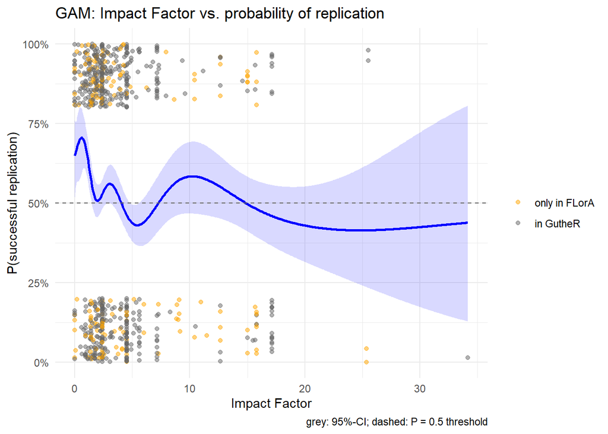

```r
## illustrating studies that are only incldued in flora but not in guther:
flora_studies$in_guther <- paste(flora_studies$doi_o, flora_studies$doi_r) %in%
                           paste(GutheR_studies$doi_o, GutheR_studies$doi_r)

ggplot(pred_gam, aes(x = impact_factor)) +
  geom_ribbon(aes(ymin = lower, ymax = upper), fill = "blue", alpha = 0.15) +
  geom_line(aes(y = prob), color = "blue", linewidth = 1) +
  geom_hline(yintercept = 0.5, linetype = "dashed", color = "gray40") +
  geom_jitter(data = flora_studies,
              aes(x = impact_factor, y = outcome_binary, color = in_guther),
              alpha = 0.5, height = 0.2, width = 0) +
  scale_color_manual(values = c("TRUE" = "gray40", "FALSE" = "orange"),
                     labels = c("TRUE" = "in GutheR", "FALSE" = "only in FLorA"),
                     name = "") +
  scale_y_continuous(limits = c(0, 1), labels = percent_format()) +
  labs(title = "GAM: Impact Factor vs. probability of replication",
       x = "Impact Factor",
       y = "P(successful replication)",
       caption = "grey: 95%-CI; dashed: P = 0.5 threshold") +
  theme_minimal()
```

```r
# Comparison of Models

##AIC
AIC(log_reg_FLorA_log, modell_gam)
```

```
                        df      AIC
log_reg_FLorA_log 2.000000 2084.815
modell_gam        8.578322 2077.787
```

```r
##McFadden R2
null_model <- glm(outcome_binary ~ 1, family = binomial, data = flora_studies)

r2_logreg <- 1 - logLik(log_reg_FLorA_log) / logLik(null_model)
r2_gam    <- 1 - logLik(modell_gam)         / logLik(null_model)

cat("McFadden R² LogReg:", round(r2_logreg, 4), "\n")
```

```
McFadden R² LogReg: 0.0063
```

```r
cat("McFadden R² GAM:   ", round(r2_gam, 4),    "\n")
```

```
McFadden R² GAM:    0.0159
```

```r
##AUC
roc_logreg <- roc(log_reg_FLorA_log$y, fitted(log_reg_FLorA_log))
auc(roc_logreg)
```

```
Area under the curve: 0.5596
```

```r
roc_gam <- roc(modell_gam$y, predict(modell_gam, type = "response"))
auc(roc_gam)
```

```
Area under the curve: 0.5819
```

```r
###############################################################################
# Does discipline confound relationship of impact factor and replicability?
###############################################################################

DISCIPLINES <- readRDS("disciplines.rds")

normalize <- function(x) {
  x <- tolower(x)
  x <- gsub("[^a-z0-9 ]", " ", x)
  x <- gsub("\\s+", " ", x)
  x <- trimws(x)
  return(x)
}

# 3. Lookup-Table:
lookup <- data.frame(
  journal_norm = normalize(unlist(DISCIPLINES)),
  discipline   = rep(names(DISCIPLINES), lengths(DISCIPLINES)),
  stringsAsFactors = FALSE
)

# 4. Matching
flora_studies$journal_norm <- normalize(flora_studies$journal_o)
flora_studies$discipline   <- lookup$discipline[
  match(flora_studies$journal_norm, lookup$journal_norm)
]

# 5. Diagnostics
cat("Matched:    ", sum(!is.na(flora_studies$discipline)), "\n")
```

```
Matched:     1515
```

```r
cat("Not found:", sum( is.na(flora_studies$discipline)), "\n")
```

```
Not found: 108
```

```r
cat("Proportion NA:     ", round(mean(is.na(flora_studies$discipline)) * 100, 1), "%\n")
```

```
Proportion NA:      6.7 %
```

```r
# How many cases per discipline
table(flora_studies$discipline, useNA = "always")
```

```
                        Biology & Life Sciences
                                            153
                          Communication & Media
                                             16
                         Computer Science & HCI
                                              7
                              Criminology & Law
                                              2
                                      Economics
                                             79
                                      Education
                                             73
                   Genetics & Molecular Biology
                                             31
                Linguistics & Language Sciences
                                             44
Management, Marketing & Organizational Behavior
                                            125
                              Medicine & Health
                                             88
                                   Neuroscience
                                             58
                        Philosophy & Humanities
                                             32
                              Political Science
                                             29
                     Psychiatry & Mental Health
                                             44
                                     Psychology
                                            684
                 Public Administration & Policy
                                              6
                    Sociology & Social Sciences
                                             20
                       Sport & Exercise Science
                                             24
                                           <NA>
                                            108
```

```r
# Basic Model (only random intercept)
modell_null <- glmer(outcome_binary ~ 1 + (1 | discipline),
                     family = binomial,
                     data = flora_studies)

# Multilevel-Model with Impact Factor
modell_ml <- glmer(outcome_binary ~ impact_factor_log + (1 | discipline),
                   family = binomial,
                   data = flora_studies)

summary(modell_ml)
```

```
Generalized linear mixed model fit by maximum likelihood (Laplace
  Approximation) [glmerMod]
 Family: binomial  ( logit )
Formula: outcome_binary ~ impact_factor_log + (1 | discipline)
   Data: flora_studies

      AIC       BIC    logLik -2*log(L)  df.resid
   2057.3    2073.3   -1025.7    2051.3      1512

Scaled residuals:
    Min      1Q  Median      3Q     Max
-2.0267 -0.9734  0.5652  0.9721  1.2606

Random effects:
 Groups     Name        Variance Std.Dev.
 discipline (Intercept) 0.1583   0.3979
Number of obs: 1515, groups:  discipline, 18

Fixed effects:
                  Estimate Std. Error z value   Pr(>|z|)
(Intercept)        0.84048    0.18705   4.493 0.00000701 ***
impact_factor_log -0.33654    0.09441  -3.565   0.000364 ***
---
Signif. codes:  0 '***' 0.001 '**' 0.01 '*' 0.05 '.' 0.1 ' ' 1

Correlation of Fixed Effects:
            (Intr)
impct_fctr_ -0.736
```

```r
# ICC: Proportion of Variance explained by discipline
# binary models: Level-1-Variance = π²/3 ≈ 3.29
tau2 <- as.numeric(VarCorr(modell_ml)$discipline)
icc  <- tau2 / (tau2 + (pi^2 / 3))
cat("ICC:", round(icc, 3), "\n")
```

```
ICC: 0.046
```

```r
# comparison: does impact factor explain variance when discipline is included?
anova(modell_null, modell_ml)
```

```
Data: flora_studies
Models:
modell_null: outcome_binary ~ 1 + (1 | discipline)
modell_ml: outcome_binary ~ impact_factor_log + (1 | discipline)
            npar    AIC    BIC  logLik -2*log(L)  Chisq Df Pr(>Chisq)
modell_null    2 2068.1 2078.7 -1032.0    2064.1
modell_ml      3 2057.3 2073.3 -1025.7    2051.3 12.733  1  0.0003593 ***
---
Signif. codes:  0 '***' 0.001 '**' 0.01 '*' 0.05 '.' 0.1 ' ' 1
```

```r
# AIC-comparison with simple LogReg without random effect
AIC(log_reg_FLorA_log, modell_null, modell_ml)#attention with interpretation it's not sound
```

```
                  df      AIC
log_reg_FLorA_log  2 2084.815
modell_null        2 2068.075
modell_ml          3 2057.342
```

```r
########################### Check of Prerequirements

#singularity
cat("Singular?:", isSingular(modell_ml, tol = 1e-4), "\n")
```

```
Singular?: FALSE
```

```r
#convergence
if (!is.null(modell_ml@optinfo$conv$lme4$messages))
  warning(paste(modell_ml@optinfo$conv$lme4$messages, collapse = " | "))

#separation
detect_sep <- glm(outcome_binary ~ impact_factor_log,
                  data   = flora_studies,
                  family = binomial,
                  method = "detect_separation")
if (detect_sep$outcome == TRUE) {
  warning("Perfect separation detected - coefficients and SE not valid")
  print(detect_sep)
} else {
  cat("No separation detected.\n")
}
```

```
No separation detected.
```

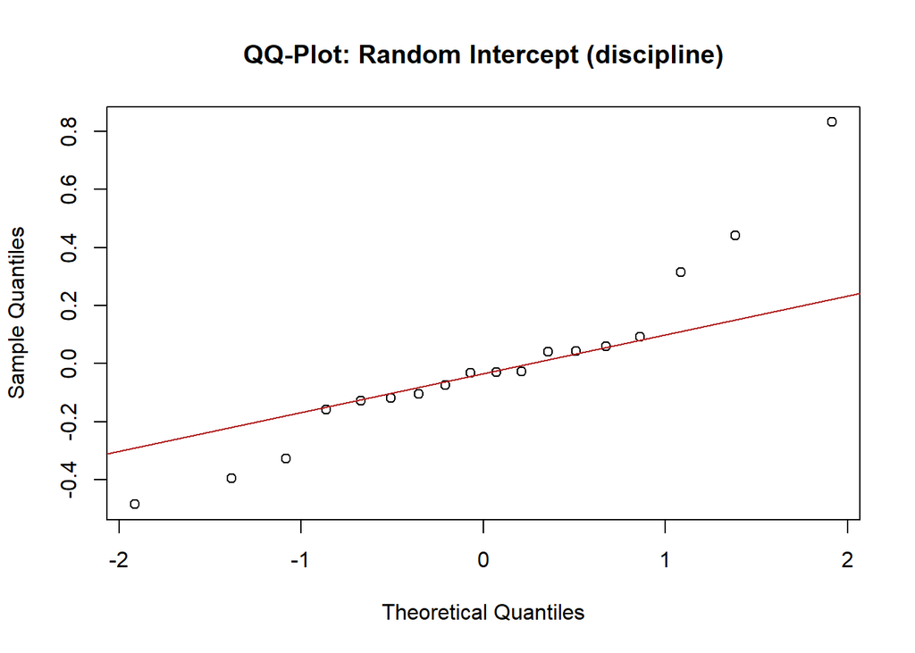

```r
# QQ-Plot Random Effects (discipline) - check for normal distribution of random effect
re <- ranef(modell_ml)$discipline
qqnorm(re[["(Intercept)"]], main = "QQ-Plot: Random Intercept (discipline)")
qqline(re[["(Intercept)"]], col = "firebrick")
```

```r
# Linearity of Predictor
flora_studies$discipline <- as.factor(flora_studies$discipline)

gam_check <- gam(
  outcome_binary ~ s(impact_factor_log) + s(discipline, bs = "re"),
  data   = flora_studies,
  family = binomial,
  method = "REML"
)
summary(gam_check)  # edf ~1 → linear; > 2-3 → non-linear
```

```
Family: binomial
Link function: logit

Formula:
outcome_binary ~ s(impact_factor_log) + s(discipline, bs = "re")

Parametric coefficients:
            Estimate Std. Error z value Pr(>|z|)
(Intercept)   0.3580     0.1296   2.763  0.00573 **
---
Signif. codes:  0 '***' 0.001 '**' 0.01 '*' 0.05 '.' 0.1 ' ' 1

Approximate significance of smooth terms:
                       edf Ref.df Chi.sq              p-value
s(impact_factor_log) 1.477  1.814  10.30              0.00288 **
s(discipline)        9.663 17.000  44.21 < 0.0000000000000002 ***
---
Signif. codes:  0 '***' 0.001 '**' 0.01 '*' 0.05 '.' 0.1 ' ' 1

R-sq.(adj) =  0.0384   Deviance explained = 3.48%
-REML = 1028.6  Scale est. = 1         n = 1515
```

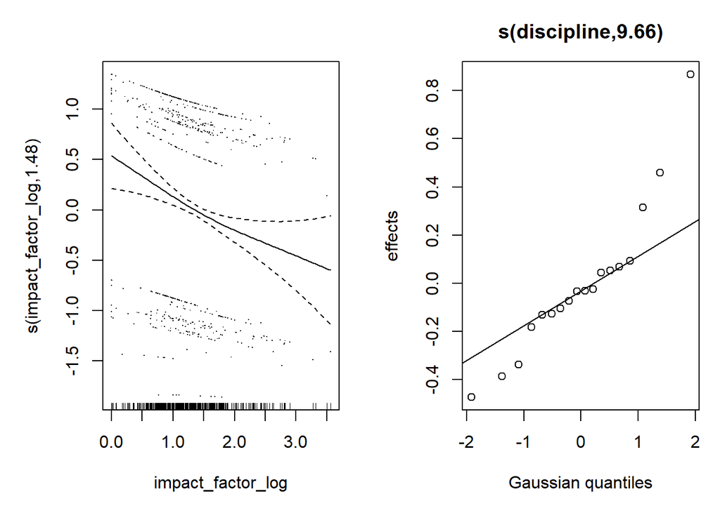

```r
plot(gam_check, pages = 1, residuals = TRUE, shade = TRUE)
```

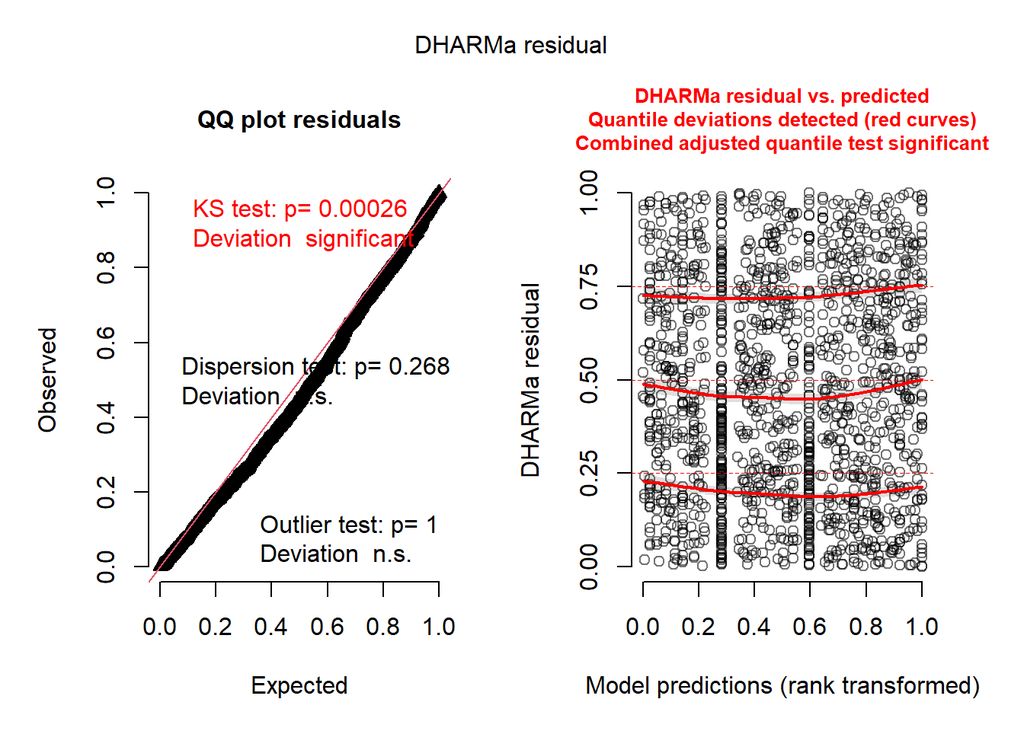

```r
#DHARMa Residuals
sim_res <- simulateResiduals(modell_ml, n = 500)
plot(sim_res)
```

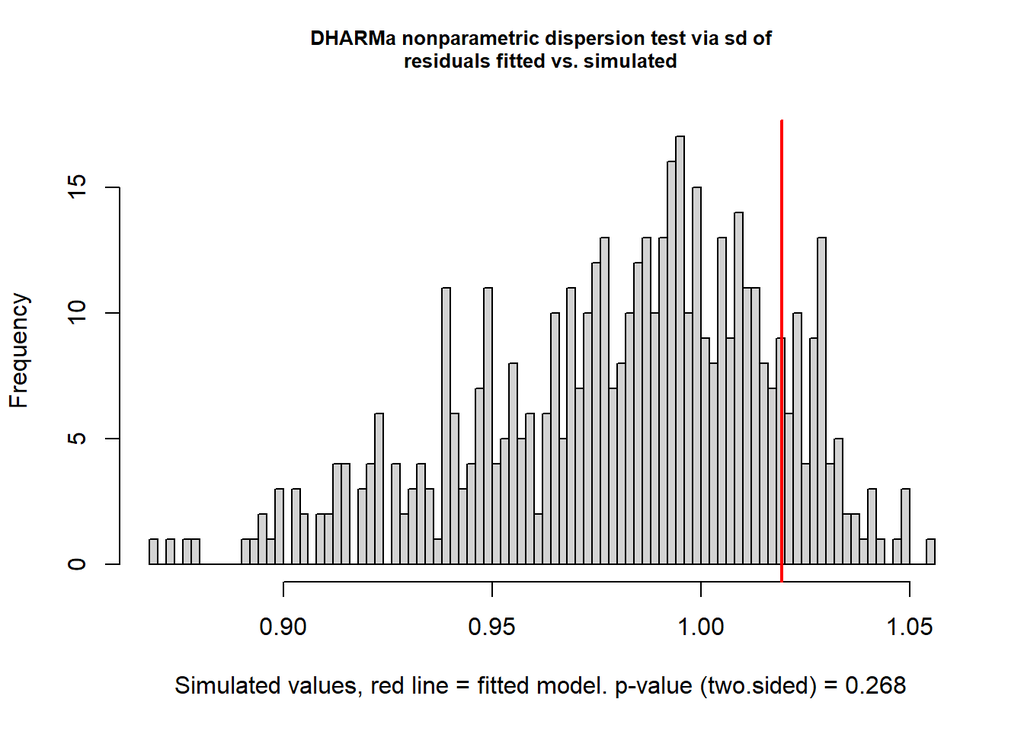

```
    DHARMa nonparametric dispersion test via sd of residuals fitted vs.
    simulated

data:  simulationOutput
dispersion = 1.0385, p-value = 0.268
alternative hypothesis: two.sided
```

```r
testDispersion(sim_res)
```

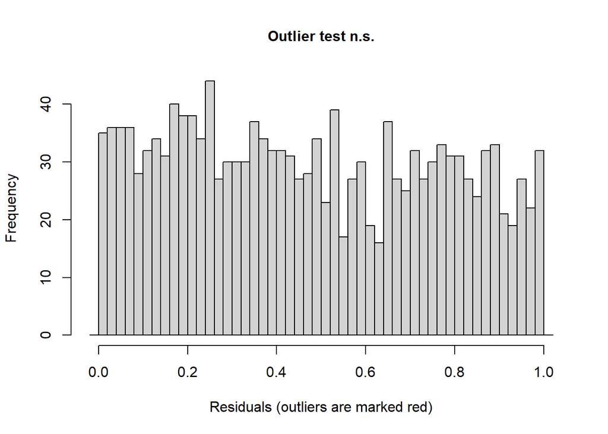

```
    DHARMa outlier test based on exact binomial test with approximate
    expectations

data:  sim_res
outliers at both margin(s) = 6, observations = 1515, p-value = 1
alternative hypothesis: true probability of success is not equal to 0.003992016
95 percent confidence interval:
 0.001454740 0.008600044
sample estimates:
frequency of outliers (expected: 0.00399201596806387 )
                                           0.003960396
```

```r
testOutliers(sim_res)
```

Although impact factor emerged as a statistically significant predictor of replication success, its practical relevance is negligible. Both logistic regression and the more flexible GAM yielded AUC values barely above chance level (0.56 and 0.58, respectively), with McFadden’s pseudo-R² below .02 across all models. Multilevel modeling further revealed that impact factor and scientific discipline are partially confounded (ICC = .046), yet impact factor retained a small but significant independent effect after accounting for disciplinary clustering. Taken together, while the effect is statistically detectable, its explanatory power is too limited for impact factor to serve as a meaningful heuristic for judging the replicability of individual studies.

```r
###############################################################################
# 4. GutheR studies analysis desciptive analysis with 2 outcomes(failed vs successful) -------------

###############################################################################
###############################################################################
# 1. filter irrelevant GutheR studies
###############################################################################

GutheR_studies <- GutheR_studies[GutheR_studies$outcome %in% c("success","failure"),]

GutheR_studies <- GutheR_studies[GutheR_studies$impact_factor<35,]

table(GutheR_studies$outcome)
```

```
failure success
    547     624
```

```r
table(GutheR_studies$outcome)/length(GutheR_studies$outcome)
```

```
  failure   success
0.4432739 0.5056726
```

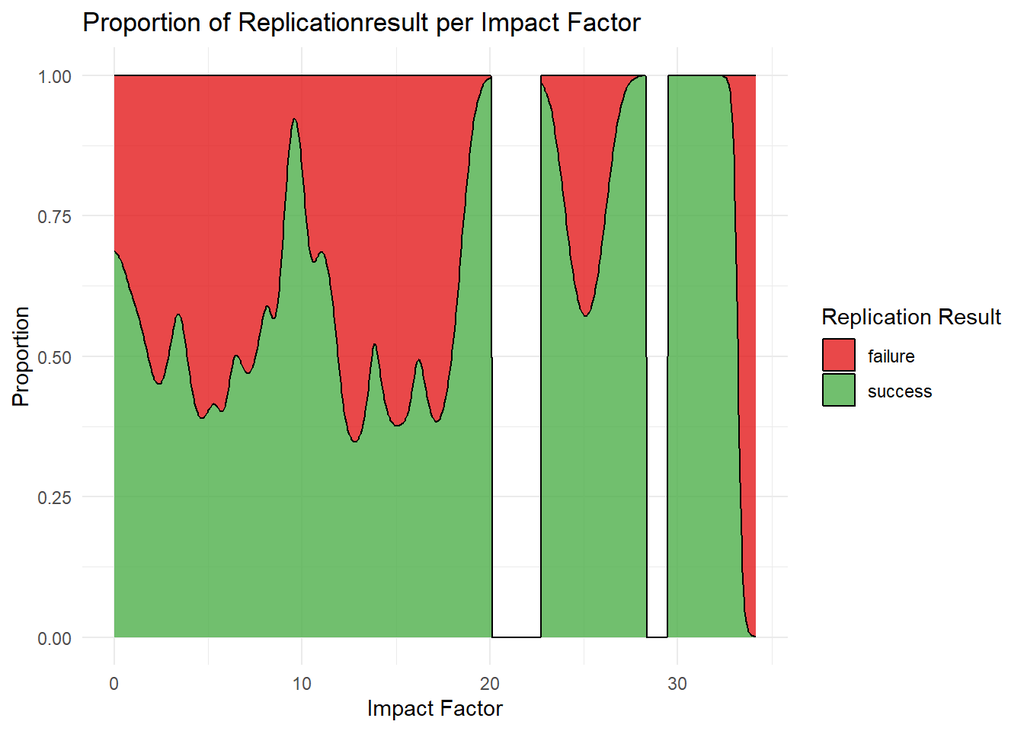

```r
###############################################################################
# 2. descriptive analysis with 2 outcomes(failure vs success) -------------
###############################################################################
GutheR_studies$outcome_fac_bin <- factor(GutheR_studies$outcome,
                                      levels = c("failure", "success"))
plot_data <- GutheR_studies[GutheR_studies$outcome %in% c("failure", "success"),]
ggplot(plot_data, aes(x = impact_factor, fill = outcome_fac_bin)) +
  geom_density(position = "fill", alpha = 0.8) +
  scale_fill_manual(values = c("failure" = "#e41a1c", "success" = "#4daf4a"),
                    name = "Replication Result") +
  labs(title = "Proportion of Replicationresult per Impact Factor",
       x = "Impact Factor",
       y = "Proportion") +
  theme_minimal()
```

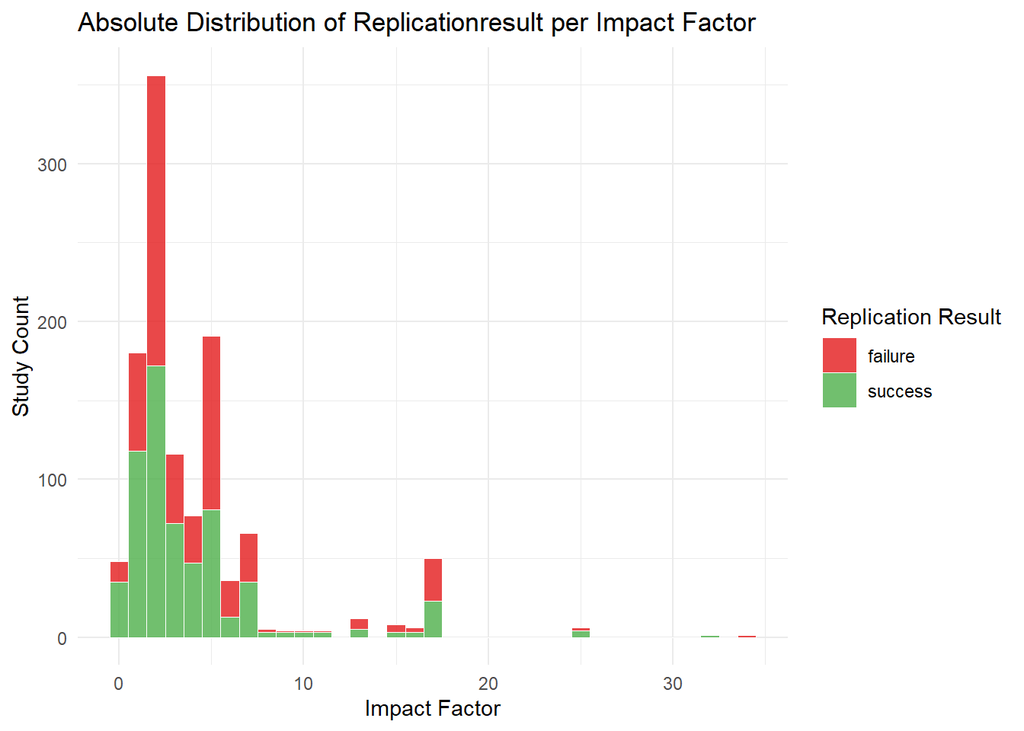

```r
ggplot(plot_data, aes(x = impact_factor, fill = outcome_fac_bin)) +
  geom_histogram(position = "stack", binwidth = 1, alpha = 0.8, color = "white", linewidth = 0.1) +
  scale_fill_manual(values = c("failure" = "#e41a1c",
                               "success" = "#4daf4a"),
                    name = "Replication Result") +
  labs(title = "Absolute Distribution of Replicationresult per Impact Factor",
       x = "Impact Factor",
       y = "Study Count") +
  theme_minimal()
```

```r
###############################################################################
# 3. Model 2 outcomes(failed vs successful) -------------
###############################################################################

GutheR_studies$outcome_binary <- ifelse(GutheR_studies$outcome == "failure", 0, ifelse(GutheR_studies$outcome == "success", 1, NA))
GutheR_studies$impact_factor_log <- log(GutheR_studies$impact_factor+1)

sum(is.na(GutheR_studies$impact_factor))
```

```
[1] 63
```

```r
sum(GutheR_studies$impact_factor == 0, na.rm = TRUE)
```

```
[1] 32
```

```r
# is log impact factor necessary for logreg?
GutheR_bt2 <- GutheR_studies[GutheR_studies$impact_factor > 0, ]
GutheR_bt2$bt_term_raw <- GutheR_bt2$impact_factor * log(GutheR_bt2$impact_factor)

log_reg_bt_raw <- glm(outcome_binary ~ impact_factor + bt_term_raw,
                      family = binomial(link = "logit"),
                      data = GutheR_bt2)
summary(log_reg_bt_raw) #yes because bt_term is sig
```

```
Call:
glm(formula = outcome_binary ~ impact_factor + bt_term_raw, family = binomial(link = "logit"),
    data = GutheR_bt2)

Coefficients:
              Estimate Std. Error z value Pr(>|z|)
(Intercept)    0.68720    0.19465   3.530 0.000415 ***
impact_factor -0.29476    0.10013  -2.944 0.003243 **
bt_term_raw    0.08762    0.03216   2.725 0.006434 **
---
Signif. codes:  0 '***' 0.001 '**' 0.01 '*' 0.05 '.' 0.1 ' ' 1

(Dispersion parameter for binomial family taken to be 1)

    Null deviance: 1575.7  on 1138  degrees of freedom
Residual deviance: 1565.1  on 1136  degrees of freedom
  (63 Beobachtungen als fehlend gelöscht)
AIC: 1571.1

Number of Fisher Scoring iterations: 4
```

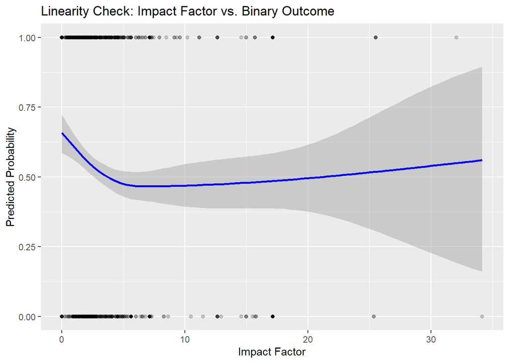

```r
ggplot(GutheR_studies, aes(x = impact_factor, y = outcome_binary)) +
  geom_point(alpha = 0.2) +
  geom_smooth(method = "gam", formula = y ~ s(x, bs = "cs"),
              method.args = list(family = binomial), color = "blue") +
  labs(title = "Linearity Check: Impact Factor vs. Binary Outcome",
       x = "Impact Factor", y = "Predicted Probability")
```

```r
# is logreg generally possible for log impact factor or is the preassumption of linearity between predictor and logodds still not met
GutheR_bt <- GutheR_studies[GutheR_studies$impact_factor_log > 0, ]
GutheR_bt$bt_term <- GutheR_bt$impact_factor_log * log(GutheR_bt$impact_factor_log)

log_reg_bt <- glm(outcome_binary ~ impact_factor_log + bt_term,
                  family = binomial(link = "logit"),
                  data = GutheR_bt)
summary(log_reg_bt)# pre requirement is not given, look at GAM and watch out for differences
```

```
Call:
glm(formula = outcome_binary ~ impact_factor_log + bt_term, family = binomial(link = "logit"),
    data = GutheR_bt)

Coefficients:
                  Estimate Std. Error z value Pr(>|z|)
(Intercept)         1.6498     0.5522   2.988  0.00281 **
impact_factor_log  -1.4194     0.5372  -2.642  0.00823 **
bt_term             0.7839     0.3614   2.169  0.03010 *
---
Signif. codes:  0 '***' 0.001 '**' 0.01 '*' 0.05 '.' 0.1 ' ' 1

(Dispersion parameter for binomial family taken to be 1)

    Null deviance: 1575.7  on 1138  degrees of freedom
Residual deviance: 1563.1  on 1136  degrees of freedom
  (63 Beobachtungen als fehlend gelöscht)
AIC: 1569.1

Number of Fisher Scoring iterations: 4
```

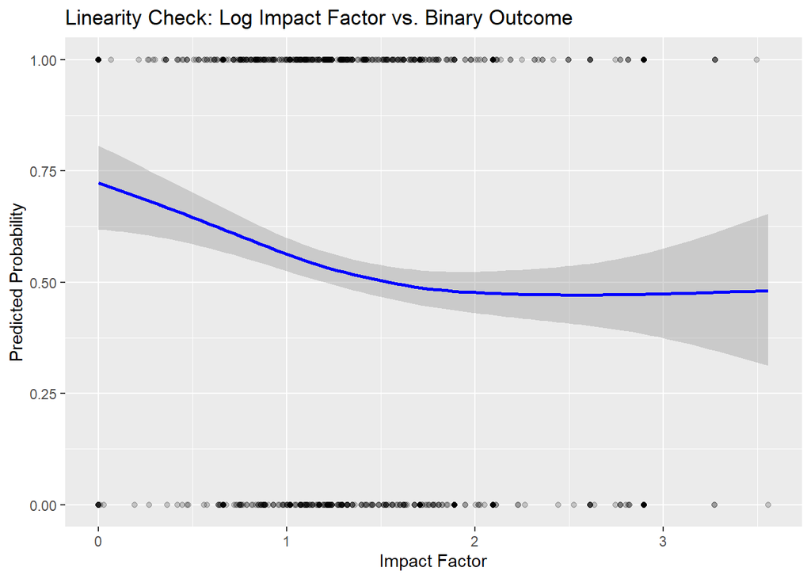

```r
ggplot(GutheR_studies, aes(x = impact_factor_log, y = outcome_binary)) +
  geom_point(alpha = 0.2) +
  geom_smooth(method = "gam", formula = y ~ s(x, bs = "cs"),
              method.args = list(family = binomial), color = "blue") +
  labs(title = "Linearity Check: Log Impact Factor vs. Binary Outcome",
       x = "Impact Factor", y = "Predicted Probability")
```

```r
# logistic regression with log impact factor
log_reg_GutheR_log <- glm(outcome_binary~impact_factor_log, family = binomial(link = "logit"), data = GutheR_studies)
summary(log_reg_GutheR_log)
```

```
Call:
glm(formula = outcome_binary ~ impact_factor_log, family = binomial(link = "logit"),
    data = GutheR_studies)

Coefficients:
                  Estimate Std. Error z value  Pr(>|z|)
(Intercept)        0.59716    0.14581   4.096 0.0000421 ***
impact_factor_log -0.33139    0.09484  -3.494  0.000476 ***
---
Signif. codes:  0 '***' 0.001 '**' 0.01 '*' 0.05 '.' 0.1 ' ' 1

(Dispersion parameter for binomial family taken to be 1)

    Null deviance: 1618.3  on 1170  degrees of freedom
Residual deviance: 1605.9  on 1169  degrees of freedom
  (63 Beobachtungen als fehlend gelöscht)
AIC: 1609.9

Number of Fisher Scoring iterations: 4
```

```r
#omni bus test
modelchi <- log_reg_GutheR_log$null.deviance - log_reg_GutheR_log$deviance
chidf <- log_reg_GutheR_log$df.null - log_reg_GutheR_log$df.residual
chisqp <- 1-pchisq(modelchi, chidf)
chisqp # model is significant overall
```

```
[1] 0.0004238959
```

```r
# OR and 95% KI
exp(cbind(OR = coef(log_reg_GutheR_log), confint(log_reg_GutheR_log)))
```

```
                         OR     2.5 %    97.5 %
(Intercept)       1.8169485 1.3674602 2.4228366
impact_factor_log 0.7179277 0.5952943 0.8636812
```

```r
#model visualisation
pred_data <- data.frame(
  impact_factor = seq(min(GutheR_studies$impact_factor, na.rm = TRUE),
                      max(GutheR_studies$impact_factor, na.rm = TRUE),
                      length.out = 500)
)
pred_data$impact_factor_log <- log(pred_data$impact_factor + 1)

pred <- predict(log_reg_GutheR_log, newdata = pred_data,
                type = "link", se.fit = TRUE)
pred_data$prob    <- plogis(pred$fit)
pred_data$lower   <- plogis(pred$fit - 1.96 * pred$se.fit)
pred_data$upper   <- plogis(pred$fit + 1.96 * pred$se.fit)

# P=0.5 Threshold: β0 + β1*log(IF+1) = 0 → IF = exp(-β0/β1) - 1
b0 <- coef(log_reg_GutheR_log)[1]
b1 <- coef(log_reg_GutheR_log)[2]
threshold_IF <- exp(-b0 / b1) - 1
cat("P(success) = 0.5 | Impact Factor:", round(threshold_IF, 2), "\n")
```

```
P(success) = 0.5 | Impact Factor: 5.06
```

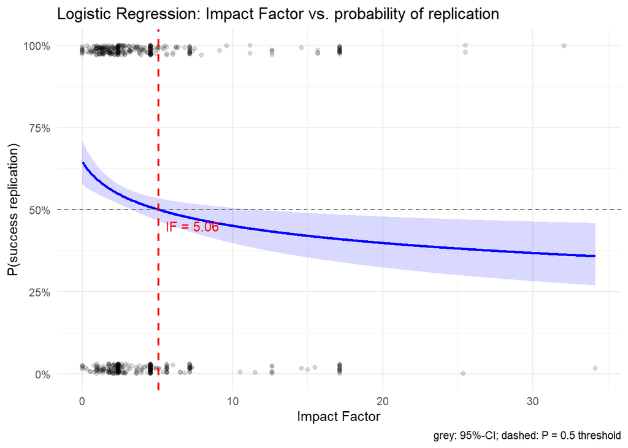

```r
ggplot(pred_data, aes(x = impact_factor)) +
  geom_ribbon(aes(ymin = lower, ymax = upper), fill = "blue", alpha = 0.15) +
  geom_line(aes(y = prob), color = "blue", linewidth = 1) +
  geom_jitter(data = GutheR_studies,
              aes(x = impact_factor, y = outcome_binary),
              alpha = 0.15, height = 0.03, width = 0) +
  geom_hline(yintercept = 0.5, linetype = "dashed", color = "gray40") +
  geom_vline(xintercept = threshold_IF, linetype = "dashed", color = "red",
             linewidth = 0.8) +
  annotate("text", x = threshold_IF + 0.5, y = 0.45,
           label = paste0("IF = ", round(threshold_IF, 2)),
           color = "red", hjust = 0) +
  scale_y_continuous(limits = c(0, 1), labels = scales::percent) +
  labs(title = "Logistic Regression: Impact Factor vs. probability of replication",
       x = "Impact Factor",
       y = "P(success replication)",
       caption = "grey: 95%-CI; dashed: P = 0.5 threshold") +
  theme_minimal()
```

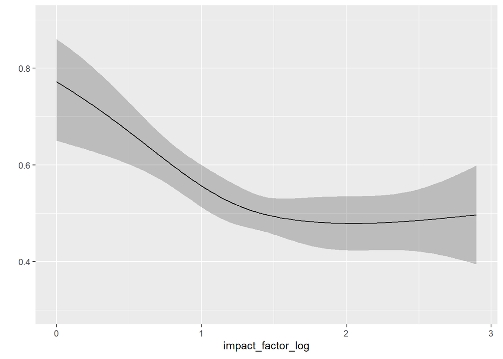

```r
#ALTERNATIVE: Restricted Cubic Splines Logistic Regression Cause box tidwell test was significant even with log impact factor:

guther_rcs_data <- GutheR_studies[!is.na(GutheR_studies$outcome_binary) &
                                   !is.na(GutheR_studies$impact_factor_log), ]

dd <- datadist(guther_rcs_data)
options(datadist = "dd")

log_reg_rcs <- lrm(outcome_binary ~ rcs(impact_factor_log, 4),
                   data = guther_rcs_data)

# Visualisierung
ggplot(Predict(log_reg_rcs, impact_factor_log, fun = plogis))
```

```r
pred_data$impact_factor_log <- log(pred_data$impact_factor + 1)

pred_rcs <- predict(log_reg_rcs,
                    newdata = pred_data,
                    type = "lp",  # link scale
                    se.fit = TRUE)

pred_data$prob_rcs  <- plogis(pred_rcs$linear.predictors)
pred_data$lower_rcs <- plogis(pred_rcs$linear.predictors - 1.96 * pred_rcs$se.fit)
pred_data$upper_rcs <- plogis(pred_rcs$linear.predictors + 1.96 * pred_rcs$se.fit)

# P=0.5 Threshold: numerical identification
crossings <- which(diff(sign(pred_data$prob_rcs - 0.5)) != 0)
threshold_IF <- pred_data$impact_factor[crossings[1]]
cat("P(success) = 0.5 | Impact Factor:", round(threshold_IF, 2), "\n")
```

```
P(success) = 0.5 | Impact Factor: 3.08
```

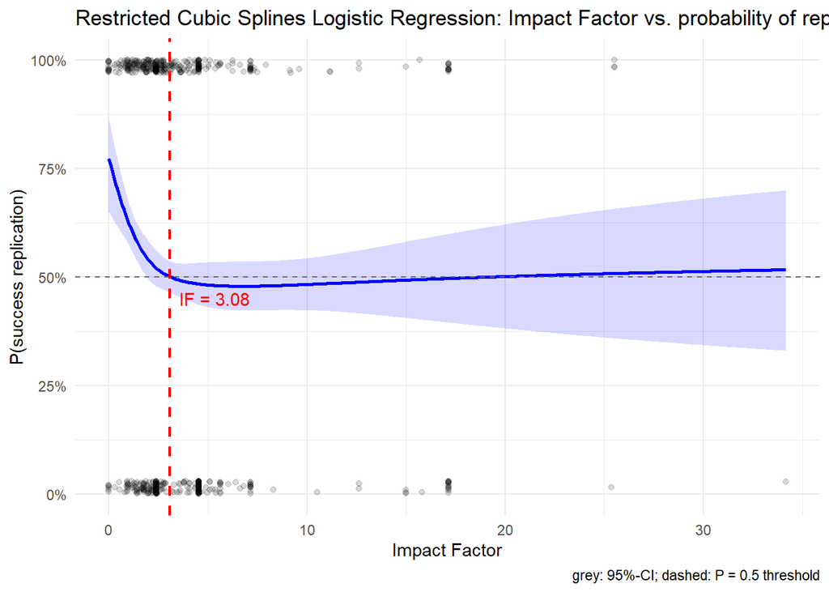

```r
ggplot(pred_data, aes(x = impact_factor)) +
  geom_ribbon(aes(ymin = lower_rcs, ymax = upper_rcs), fill = "blue", alpha = 0.15) +
  geom_line(aes(y = prob_rcs), color = "blue", linewidth = 1) +
  geom_jitter(data = GutheR_studies,
              aes(x = impact_factor, y = outcome_binary),
              alpha = 0.15, height = 0.03, width = 0) +
  geom_hline(yintercept = 0.5, linetype = "dashed", color = "gray40") +
  geom_vline(xintercept = threshold_IF, linetype = "dashed", color = "red",
             linewidth = 0.8) +
  annotate("text", x = threshold_IF + 0.5, y = 0.45,
           label = paste0("IF = ", round(threshold_IF, 2)),
           color = "red", hjust = 0) +
  scale_y_continuous(limits = c(0, 1), labels = scales::percent) +
  labs(title = "Restricted Cubic Splines Logistic Regression: Impact Factor vs. probability of replication",
       x = "Impact Factor",
       y = "P(success replication)",
       caption = "grey: 95%-CI; dashed: P = 0.5 threshold") +
  theme_minimal()
```

```r
#GAM model
modell_gam <- gam(outcome_binary ~ s(impact_factor_log), data = GutheR_studies, family = binomial)
summary(modell_gam)
```

```
Family: binomial
Link function: logit

Formula:
outcome_binary ~ s(impact_factor_log)

Parametric coefficients:
            Estimate Std. Error z value Pr(>|z|)
(Intercept)  0.13558    0.05904   2.296   0.0216 *
---
Signif. codes:  0 '***' 0.001 '**' 0.01 '*' 0.05 '.' 0.1 ' ' 1

Approximate significance of smooth terms:
                       edf Ref.df Chi.sq  p-value
s(impact_factor_log) 2.294  2.895  17.98 0.000519 ***
---
Signif. codes:  0 '***' 0.001 '**' 0.01 '*' 0.05 '.' 0.1 ' ' 1

R-sq.(adj) =  0.0152   Deviance explained = 1.27%
UBRE = 0.37007  Scale est. = 1         n = 1171
```

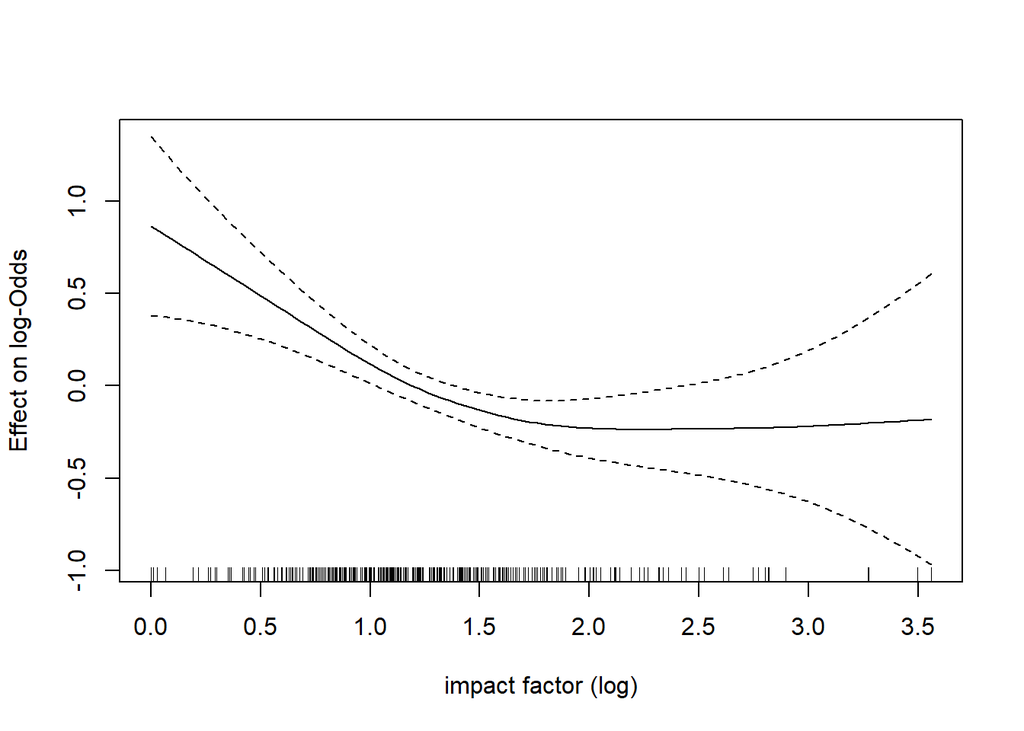

```r
plot(modell_gam, shade = TRUE,
     xlab = "impact factor (log)",
     ylab = "Effect on log-Odds")
```

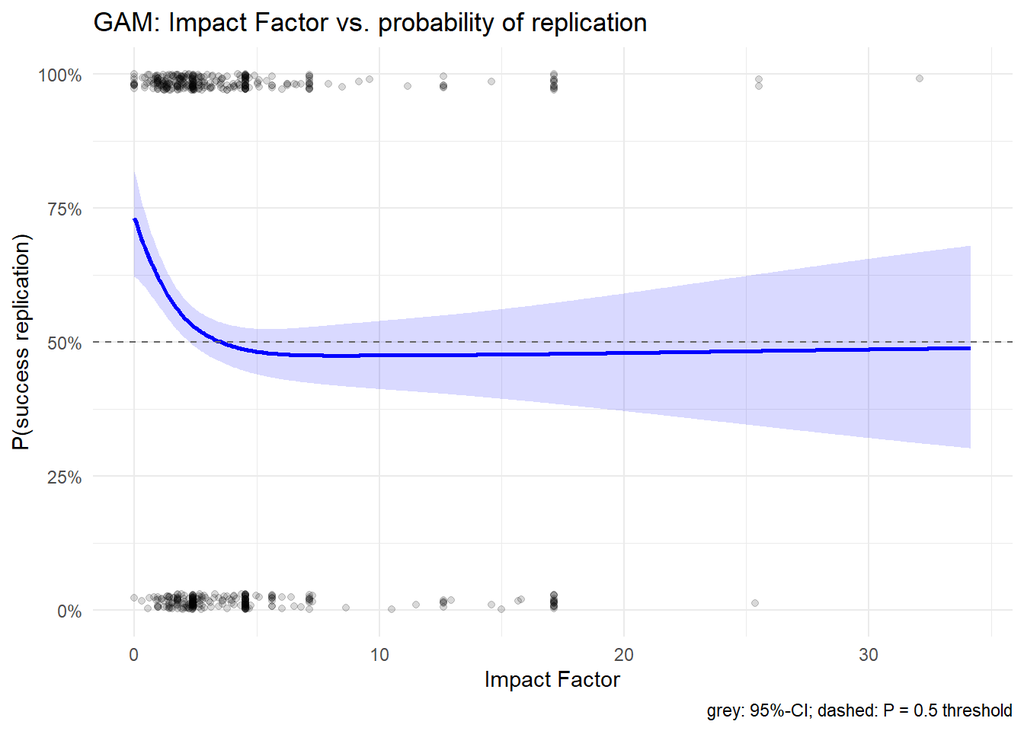

```r
# model prediction on original Impact Factor scale
pred_gam <- data.frame(
  impact_factor = seq(min(GutheR_studies$impact_factor, na.rm = TRUE),
                      max(GutheR_studies$impact_factor, na.rm = TRUE),
                      length.out = 500)
)
pred_gam$impact_factor_log <- log(pred_gam$impact_factor + 1)

# calculate CI on link scale, then transform on probabilities
pred <- predict(modell_gam, newdata = pred_gam, type = "link", se.fit = TRUE)
pred_gam$prob  <- plogis(pred$fit)
pred_gam$lower <- plogis(pred$fit - 1.96 * pred$se.fit)
pred_gam$upper <- plogis(pred$fit + 1.96 * pred$se.fit)

ggplot(pred_gam, aes(x = impact_factor)) +
  geom_ribbon(aes(ymin = lower, ymax = upper), fill = "blue", alpha = 0.15) +
  geom_line(aes(y = prob), color = "blue", linewidth = 1) +
  geom_hline(yintercept = 0.5, linetype = "dashed", color = "gray40") +
  geom_jitter(data = GutheR_studies,
              aes(x = impact_factor, y = outcome_binary),
              alpha = 0.15, height = 0.03, width = 0) +
  scale_y_continuous(limits = c(0, 1), labels = percent_format()) +
  labs(title = "GAM: Impact Factor vs. probability of replication",
       x = "Impact Factor",
       y = "P(success replication)",
       caption = "grey: 95%-CI; dashed: P = 0.5 threshold") +
  theme_minimal()
```

```r
# Comparison of Models

##AIC
AIC(log_reg_GutheR_log, modell_gam, log_reg_rcs)
```

```
                         df      AIC
log_reg_GutheR_log 2.000000 1609.860
modell_gam         3.293847 1604.347
log_reg_rcs        4.000000 1605.353
```

```r
##McFadden R2
null_model <- glm(outcome_binary ~ 1, family = binomial, data = GutheR_studies)

r2_logreg <- 1 - logLik(log_reg_GutheR_log) / logLik(null_model)
r2_gam    <- 1 - logLik(modell_gam)         / logLik(null_model)
r2_rcs    <- 1 - logLik(log_reg_rcs)         / logLik(null_model)

cat("McFadden R² LogReg:", round(r2_logreg, 4), "\n")
```

```
McFadden R² LogReg: 0.0077
```

```r
cat("McFadden R² GAM:   ", round(r2_gam, 4),    "\n")
```

```
McFadden R² GAM:    0.0127
```

```r
cat("McFadden R² RCS:   ", round(r2_rcs,    4), "\n")
```

```
McFadden R² RCS:    0.0129
```

```r
##AUC
roc_logreg <- roc(log_reg_GutheR_log$y, fitted(log_reg_GutheR_log))
auc(roc_logreg)
```

```
Area under the curve: 0.5645
```

```r
roc_gam <- roc(modell_gam$y, predict(modell_gam, type = "response"))
auc(roc_gam)
```

```
Area under the curve: 0.563
```

```r
roc_rcs <- roc(guther_rcs_data$outcome_binary,
               plogis(log_reg_rcs$linear.predictors))
auc(roc_rcs)
```

```
Area under the curve: 0.5651
```

```r
###############################################################################
# Does discipline confound relationship of impact factor and replicability?
###############################################################################

DISCIPLINES <- readRDS("disciplines.rds")

normalize <- function(x) {
  x <- tolower(x)
  x <- gsub("[^a-z0-9 ]", " ", x)
  x <- gsub("\\s+", " ", x)
  x <- trimws(x)
  return(x)
}

# 3. Lookup-Table:
lookup <- data.frame(
  journal_norm = normalize(unlist(DISCIPLINES)),
  discipline   = rep(names(DISCIPLINES), lengths(DISCIPLINES)),
  stringsAsFactors = FALSE
)

# 4. Matching
GutheR_studies$journal_norm <- normalize(GutheR_studies$journal)
GutheR_studies$discipline   <- lookup$discipline[
  match(GutheR_studies$journal_norm, lookup$journal_norm)
]

# 5. Diagnostics
cat("Matched:    ", sum(!is.na(GutheR_studies$discipline)), "\n")
```

```
Matched:     1171
```

```r
cat("Not found:", sum( is.na(GutheR_studies$discipline)), "\n")
```

```
Not found: 63
```

```r
cat("Proportion NA:     ", round(mean(is.na(GutheR_studies$discipline)) * 100, 1), "%\n")
```

```
Proportion NA:      5.1 %
```

```r
# How many cases per discipline
table(GutheR_studies$discipline, useNA = "always")
```

```
                        Biology & Life Sciences
                                            124
                          Communication & Media
                                             14
                         Computer Science & HCI
                                              7
                              Criminology & Law
                                              2
                                      Economics
                                             48
                                      Education
                                             57
                   Genetics & Molecular Biology
                                             15
                Linguistics & Language Sciences
                                             32
Management, Marketing & Organizational Behavior
                                             92
                              Medicine & Health
                                             70
                                   Neuroscience
                                             33
                        Philosophy & Humanities
                                             25
                              Political Science
                                             26
                     Psychiatry & Mental Health
                                             34
                                     Psychology
                                            554
                 Public Administration & Policy
                                              6
                    Sociology & Social Sciences
                                             12
                       Sport & Exercise Science
                                             20
                                           <NA>
                                             63
```

```r
# Basic Model (only random intercept)
modell_null <- glmer(outcome_binary ~ 1 + (1 | discipline),
                     family = binomial,
                     data = GutheR_studies)

# Multilevel-Model with Impact Factor
modell_ml <- glmer(outcome_binary ~ impact_factor_log + (1 | discipline),
                   family = binomial,
                   data = GutheR_studies)

summary(modell_ml)
```

```
Generalized linear mixed model fit by maximum likelihood (Laplace
  Approximation) [glmerMod]
 Family: binomial  ( logit )
Formula: outcome_binary ~ impact_factor_log + (1 | discipline)
   Data: GutheR_studies

      AIC       BIC    logLik -2*log(L)  df.resid
   1585.3    1600.5    -789.6    1579.3      1168

Scaled residuals:
    Min      1Q  Median      3Q     Max
-2.0005 -0.9679  0.5438  0.9726  1.2198

Random effects:
 Groups     Name        Variance Std.Dev.
 discipline (Intercept) 0.1796   0.4238
Number of obs: 1171, groups:  discipline, 18

Fixed effects:
                  Estimate Std. Error z value  Pr(>|z|)
(Intercept)         0.9480     0.2154   4.402 0.0000107 ***
impact_factor_log  -0.3961     0.1157  -3.424  0.000616 ***
---
Signif. codes:  0 '***' 0.001 '**' 0.01 '*' 0.05 '.' 0.1 ' ' 1

Correlation of Fixed Effects:
            (Intr)
impct_fctr_ -0.761
```

```r
# ICC: Proportion of Variance explained by discipline
# binary models: Level-1-Variance = π²/3 ≈ 3.29
tau2 <- as.numeric(VarCorr(modell_ml)$discipline)
icc  <- tau2 / (tau2 + (pi^2 / 3))
cat("ICC:", round(icc, 3), "\n")
```

```
ICC: 0.052
```

```r
# comparison: does impact factor explain variance when discipline is included?
anova(modell_null, modell_ml)
```

```
Data: GutheR_studies
Models:
modell_null: outcome_binary ~ 1 + (1 | discipline)
modell_ml: outcome_binary ~ impact_factor_log + (1 | discipline)
            npar    AIC    BIC  logLik -2*log(L) Chisq Df Pr(>Chisq)
modell_null    2 1595.0 1605.1 -795.51    1591.0
modell_ml      3 1585.3 1600.5 -789.65    1579.3 11.72  1  0.0006182 ***
---
Signif. codes:  0 '***' 0.001 '**' 0.01 '*' 0.05 '.' 0.1 ' ' 1
```

```r
# AIC-comparison with simple LogReg without random effect
AIC(log_reg_GutheR_log, modell_null, modell_ml)#attention with interpretation it's not sound
```

```
                   df      AIC
log_reg_GutheR_log  2 1609.860
modell_null         2 1595.012
modell_ml           3 1585.292
```

```r
########################### Check of Prerequirements

#singularity
cat("Singular?:", isSingular(modell_ml, tol = 1e-4), "\n")
```

```
Singular?: FALSE
```

```r
#convergence
if (!is.null(modell_ml@optinfo$conv$lme4$messages))
  warning(paste(modell_ml@optinfo$conv$lme4$messages, collapse = " | "))

#separation
detect_sep <- glm(outcome_binary ~ impact_factor_log,
                  data   = GutheR_studies,
                  family = binomial,
                  method = "detect_separation")
if (detect_sep$outcome == TRUE) {
  warning("Perfect separation detected - coefficients and SE not valid")
  print(detect_sep)
} else {
  cat("No separation detected.\n")
}
```

```
No separation detected.
```

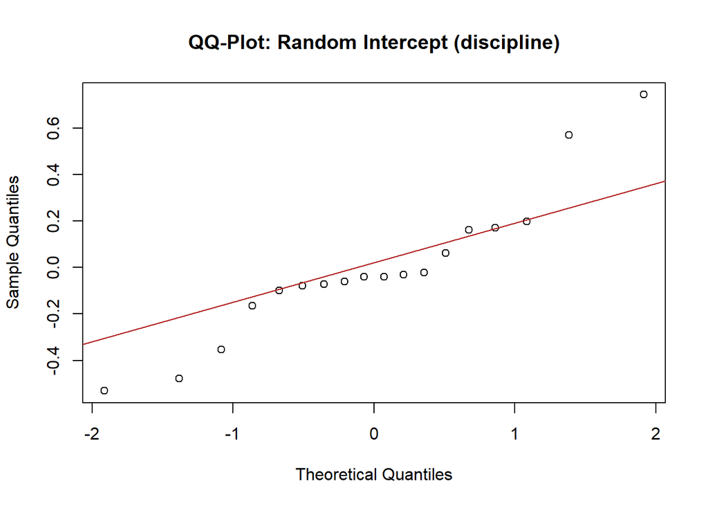

```r
# QQ-Plot Random Effects (discipline) - check for normal distribution of random effect
re <- ranef(modell_ml)$discipline
qqnorm(re[["(Intercept)"]], main = "QQ-Plot: Random Intercept (discipline)")
qqline(re[["(Intercept)"]], col = "firebrick")
```

```r
# Linearity of Predictor
GutheR_studies$discipline <- as.factor(GutheR_studies$discipline)

gam_check <- gam(
  outcome_binary ~ s(impact_factor_log) + s(discipline, bs = "re"),
  data   = GutheR_studies,
  family = binomial,
  method = "REML"
)
summary(gam_check)  # edf ~1 → linear; > 2-3 → non-linear
```

```
Family: binomial
Link function: logit

Formula:
outcome_binary ~ s(impact_factor_log) + s(discipline, bs = "re")

Parametric coefficients:
            Estimate Std. Error z value Pr(>|z|)
(Intercept)   0.3826     0.1414   2.705  0.00682 **
---
Signif. codes:  0 '***' 0.001 '**' 0.01 '*' 0.05 '.' 0.1 ' ' 1

Approximate significance of smooth terms:
                       edf Ref.df Chi.sq    p-value
s(impact_factor_log) 1.815  2.287  13.13     0.0028 **
s(discipline)        9.013 17.000  38.35 0.00000327 ***
---
Signif. codes:  0 '***' 0.001 '**' 0.01 '*' 0.05 '.' 0.1 ' ' 1

R-sq.(adj) =  0.0457   Deviance explained = 4.18%
-REML = 792.12  Scale est. = 1         n = 1171
```

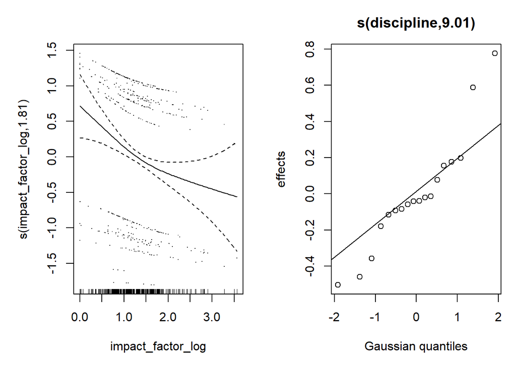

```r
plot(gam_check, pages = 1, residuals = TRUE, shade = TRUE)
```

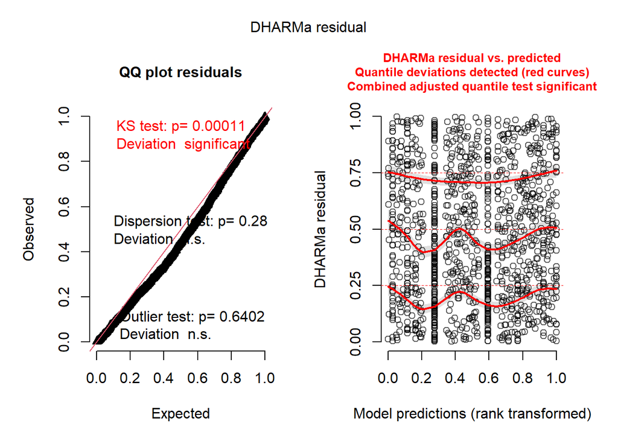

```r
#DHARMa Residuals
sim_res <- simulateResiduals(modell_ml, n = 500)
plot(sim_res)
```

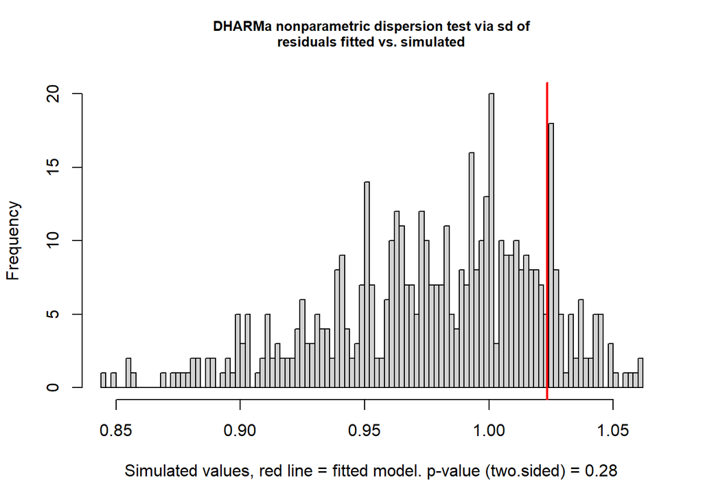

```
    DHARMa nonparametric dispersion test via sd of residuals fitted vs.
    simulated

data:  simulationOutput
dispersion = 1.0466, p-value = 0.28
alternative hypothesis: two.sided
```

```r
testDispersion(sim_res)
```

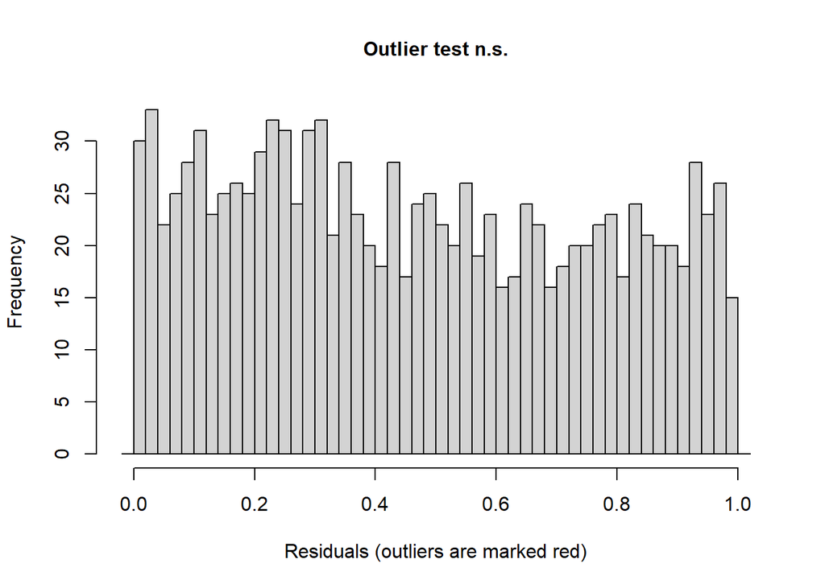

```
    DHARMa outlier test based on exact binomial test with approximate
    expectations

data:  sim_res
outliers at both margin(s) = 3, observations = 1171, p-value = 0.6402
alternative hypothesis: true probability of success is not equal to 0.003992016
95 percent confidence interval:
 0.000528640 0.007468579
sample estimates:
frequency of outliers (expected: 0.00399201596806387 )
                                           0.002561913
```

```r
testOutliers(sim_res)
```

Although impact factor emerged as a statistically significant predictor of replication success over different models like logistic regression, GAM and restricted cubic splines logistic regression, its practical relevance is negligible. The Box-Tidwell test indicated a violation of the linearity assumption for logistic regression even after log-transformation, favoring more flexible approaches. Nonetheless, GAM and Restricted Cubic Splines yielded no meaningful improvement over simple logistic regression, with AUC values across all three models hovering around 0.56 and McFadden’s pseudo-R² ranging from .008 to .013. The RCS model identified a threshold of P(success) = 0.5 at an impact factor of approximately 3.1, though the wide confidence intervals and negligible model fit limit the interpretability of this estimate. Multilevel modeling revealed that scientific discipline accounts for a small but non-trivial share of variance in replication success (ICC = .052), and impact factor and discipline are partially confounded. Nevertheless, impact factor retained a small independent effect after accounting for disciplinary clustering (β = −0.40, p < .001). Model diagnostics indicated no issues with overdispersion, outliers, or separation. Taken together, while the effect of impact factor is statistically detectable and robust across model specifications, its explanatory power is too limited to serve as a meaningful heuristic for judging the replicability of individual studies.

```r
#####################################################################
# Where are differences between the two datasets
#####################################################################

# Distribution of impact_factor_log
summary(GutheR_studies$impact_factor_log)
```

```
   Min. 1st Qu.  Median    Mean 3rd Qu.    Max.    NA's
  0.000   1.019   1.270   1.401   1.708   3.560      63
```

```r
summary(flora_studies$impact_factor_log)
```

```
   Min. 1st Qu.  Median    Mean 3rd Qu.    Max.    NA's
  0.000   1.019   1.250   1.418   1.708   3.560     108
```

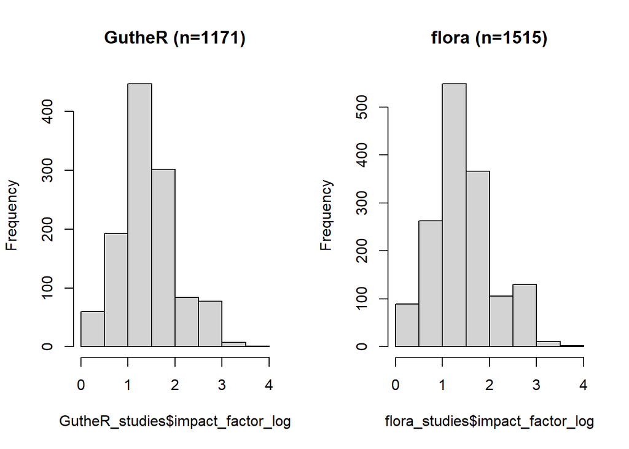

```r
# Visual comparison
par(mfrow = c(1, 2))
hist(GutheR_studies$impact_factor_log, main = "GutheR (n=1171)")
hist(flora_studies$impact_factor_log, main = "flora (n=1515)")
```

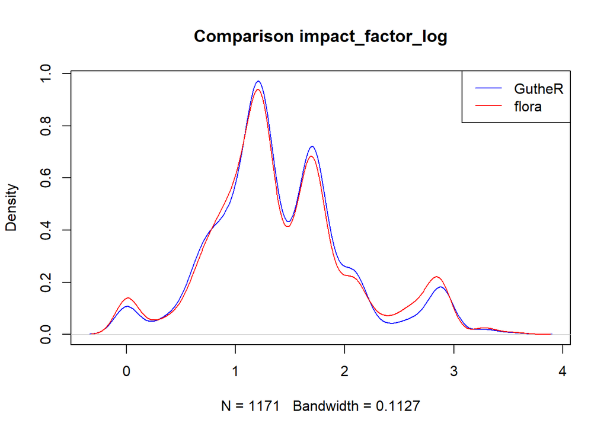

```r
par(mfrow = c(1, 1))

# Density comparison
plot(density(GutheR_studies$impact_factor_log, na.rm = TRUE), col = "blue", main = "Comparison impact_factor_log")
lines(density(flora_studies$impact_factor_log, na.rm = TRUE), col = "red")
legend("topright", c("GutheR", "flora"), col = c("blue", "red"), lty = 1)
```

```r
# outcome_binary distribution
prop.table(table(GutheR_studies$outcome_binary))
```

```
        0         1
0.4671221 0.5328779
```

```r
prop.table(table(flora_studies$outcome_binary))
```

```
        0         1
0.4679868 0.5320132
```